DSAIDE - Dynamical Systems Approach to Infectious Disease Epidemiology

A collection of Shiny/R Apps to explore and simulate the population dynamics of infectious diseases.  
Written and maintained by [Andreas Handel](http://handelgroup.uga.edu), with contributions from others.

# Direct Transmission Modes - Practice

## Overview

This app allows you to explore a model with 2 different modes of direct transmission. Read about the model in the “Model” tab. Then do the tasks described in the “What to do” tab.

## The Model

### Model Overview

This is a simple SIR model with births and deaths and 2 types of direct transmission, density-dependent and frequency-dependent (based on the terminology in (Begon et al. 2002) - see *Further Information* tab for references).

This model has the following compartments:

- **S** - uninfected and susceptible individuals
- **I** - individuals who are infected and infectious.
- **R** - recovered/removed individuals.

The processes being modeled are:

- Susceptible individuals can become infected by two types of direct transmission from infected hosts, further described below.
- Infected hosts recover after some time (specified by the rate *g*).
- Recovered individuals are initially immune to reinfection. They can loose their immunity at rate *w* and return back to the susceptible compartment.
- New susceptibles enter (are born) at a fixed rate *b*. From each compartment, hosts “leave” after some time (i.e. they die) at rate *n*. The inverse of this rate is the average lifespan of a host.

The force of infection, $\lambda$, depends on the transmission model. For density-dependent transmission, it is given by $\lambda = b_d I / A$, where *A* is the area of the scenario under consideration (e.g. a city). For frequency-dependent transmission, we have $\lambda = b_f I / N$, where *N* is the size of the population, *N=S+I+R*.

### Model Implementation

The flow diagram and the set of ordinary differential equations (ODE) which are used to implement this model are as follows:

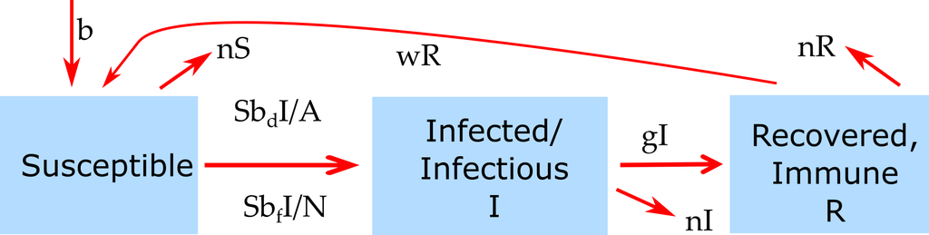

Flow diagram for this model.

$$\dot S =b - \lambda S + wR - nS$$
$$\dot I = \lambda S - g I -nI$$
$$\dot R = g I - wR - nR$$

with $\lambda = b_d I / A$ for density-dependent transmission and $\lambda = b_f I / N$ for frequency-dependent transmission.

### Model Comments

Note that quite often, we assume that the area is constant and do not include it in the model or even talk about it. Often, the population size is also assumed to be constant. In that case, the 2 types of transmission models behave the same. But as soon as area or population size change, the model results differ. Which is what you can explore with this simulation.

## What to do

*A general note: Some of the tasks below are fairly open ended. You shouldn’t go through the tasks like a check-list. Instead, explore these simulations, play with them, query them. As you do, loop through iterations of formulating your expectations for a specific scenario/task, running the model and observing results, and if results don’t agree with your expectations, figure out why. Essentially, **“do science/research”**.*

### Task 1:

- Set the model parameters such that it corresponds to the following setting:
  - A population size of 1000, 1 initially infected host, simulation duration approximately 10 years.
  - Consider density-dependent transmission, with a transmission rate of b<sub>d</sub> = 0.005, area of size 2.
  - Assume that the duration of the infectious period is 15 days long (and that there are 30 days in a month).
  - Turn off births, deaths and waning immunity for now.
- With parameters set to correspond to the scenario just described, run the simulation.
- Record the number and fraction of susceptible/infected/recovered remaining at the end of the outbreak.

### Task 2:

- Now switch to frequency-dependent transmission, set b<sub>f</sub>=2.5. Keep everything else as before.
- Think about your expectations, run the simulation and compare your expectations with the results.
- Anything surprising happening? Do you understand why you are seeing what you see?

### Task 3:

- Let’s assume we are now in a location with twice the number of people as before, living in roughly the same area.
- Implement that in the simulation by changing population size, keep all other settings as above.
- What do you expect to see for the frequency and density dependent scenarios? Run simulations and check. Pay attention to both the numbers and fractions of S/I/R individuals at the end of the outbreak.

### Task 4:

- If you double the population size as you just did, how do you need to adjust the area to obtain the same sized outbreak (in terms of fraction of people getting infected/remaining susceptible) for density-dependent transmission?
- Try with the simulation if your expectation is correct.

### Task 5:

- Keep exploring by trying different parameters and transmission settings and see how they influence results.
- You can also go beyond a single outbreak and turn on births/deaths (which can impact population size) or waning immunity.
- As you continue your exploration, think about potential real infectious diseases that might be approximated by either one of the transmission types, and what approximate choices for the model parameters would describe those IDs.

## Answers

This section does not have the shinytab label and is therefore ignored and not included in the app. One could provide the answers here. Note that if this file is supplied with the package, the answers are in principle available, so most users might not know where/how to look.

## Further Information

- For this app, the underlying function running the simulation is called `simulate_directtransmission.R`. You can call this function directly, without going through the shiny app. Check the help file for the function for more information. If you go that route, you need to use the results returned from this function and produce useful output (such as a plot) yourself.
- You could also modify this R function for your own purposes - though that requires R coding knowledge.

### References

This package is built and maintained by [Andreas Handel](http://handelgroup.uga.edu/), with contributions from others.  
All text and figures are licensed under a [Creative Commons Attribution-NonCommercial-ShareAlike 4.0 International License](http://creativecommons.org/licenses/by-nc-sa/4.0/). Software/Code is licensed under [GPL-3](https://www.gnu.org/licenses/gpl-3.0.en.html).